# Análise da precisão

```r
library(tidyverse)
library(here)
library(modelr)
library(broom)
library(tm)
library(tidytext)
library(GGally)
theme_set(theme_bw())
```

## Os dados

```r
reclamacoes_raw = read_csv(here("data/reclamacoes-raw/reclamacoes-raw.csv"))
avaliacoes_raw = read_csv(here("data/avaliacoes/avaliacoes-20180222.csv"))
sentimentos = read_csv(here("data/sentimentos/sentimento.csv"))
```

`reclamacoes_l` tem um formato long em vez de wide (explicado [aqui](https://sejdemyr.github.io/r-tutorials/basics/wide-and-long/)).

```r
avaliacoes = avaliacoes_raw %>%
    group_by(id_reclamação) %>%
    summarise(insatisfação = median(insatisfação),
              avaliadores = n())

reclamacoes = reclamacoes_raw %>%
    inner_join(avaliacoes, by = c("id" = "id_reclamação")) %>%
    left_join(sentimentos, by = "id")

reclamacoes_l = reclamacoes %>%
    select(-palavras_op30, -palavras_sent) %>%
    gather(key = "lexico",
           value = "polaridade",
           sentimento_op30, sentimento_sent)

reclamacoes_l = reclamacoes_l %>%
    mutate(lexico_id = ifelse(lexico == "sentimento_op30", 0, 1))
```

Converte polaridades para escala 0-5

```r
reclamacoes_l = reclamacoes_l %>%
    group_by(lexico) %>%
    mutate(polaridade_normalizada = round(
        (polaridade-min(polaridade))/(max(polaridade)-min(polaridade)) * 5,
        digits=2
    ))
```

Calcula o erro por reclamação

```r
reclamacoes_l = reclamacoes_l %>%
    mutate(erro = sqrt((insatisfação - polaridade_normalizada)**2))
```

## EDA

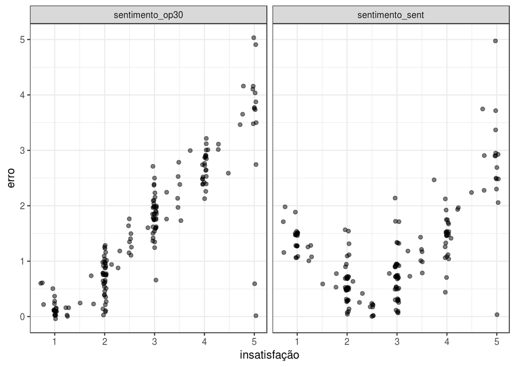

```r
reclamacoes_l %>%
    ggplot(aes(x = insatisfação, y = erro, group = insatisfação)) +
    geom_jitter(alpha = .5, width = .04, height = .04)  +
    facet_wrap(~ lexico)
```

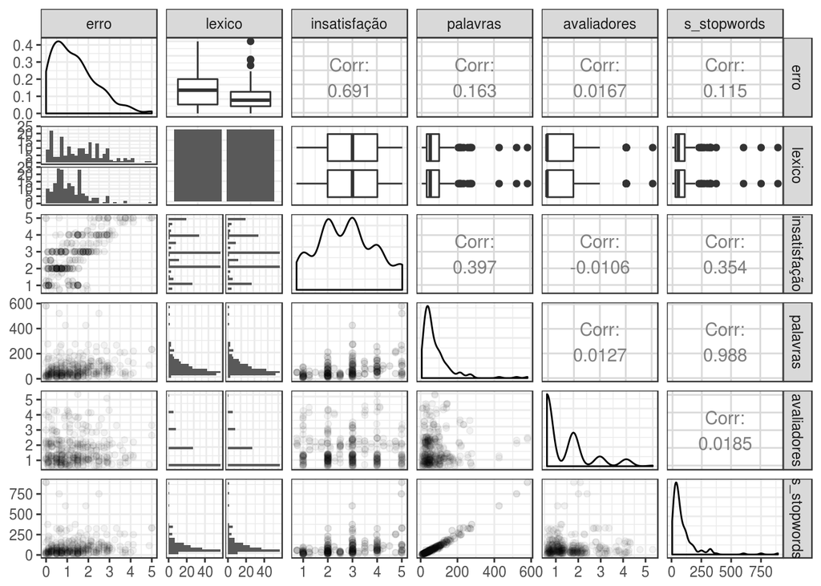

```r
jitter <- function(data, mapping){
  p <- ggplot(data = data, mapping = mapping) +
    geom_jitter(alpha = .05)
  p
}

reclamacoes_l %>%
    select(erro, lexico, insatisfação, palavras, avaliadores, s_stopwords) %>%
    na.omit() %>%
    ggpairs(lower = list(continuous = jitter))
```

A correlaçaõ é um índice que indica como duas variáveis variam juntas, sendo representada por um valor entre -1 e 1. Quanto mais próximo de -1 ou 1, mais forte é essa relação. Se positiva, então as variáveis crescem juntas. A insatisfação tem alta correlação com o erro, portanto parece ser uma boa variável independente para o modelo. Outra variável independente interessante é o tipo de léxico, visto que nosso objetivo é também comparar os léxicos. As outras variáveis têm pouca correlação com o erro.

## Há relação entre o léxico e a precisão/erro?

Agora um modelo para responder sua pergunta.

```r
modelo = lm(erro ~ insatisfação + lexico_id, data = reclamacoes_l)

tidy(modelo, conf.int = TRUE, conf.level = 0.95)
```

```
##           term    estimate  std.error  statistic      p.value   conf.low
## 1  (Intercept) -0.09882052 0.10389186 -0.9511863 3.421681e-01 -0.3031534
## 2 insatisfação  0.60374208 0.03192216 18.9129431 2.034471e-55  0.5409581
## 3    lexico_id -0.48681818 0.07508595 -6.4834787 3.062670e-10 -0.6344961
##    conf.high
## 1  0.1055124
## 2  0.6665261
## 3 -0.3391403
```

```r
glance(modelo)
```

```
##   r.squared adj.r.squared     sigma statistic      p.value df    logLik
## 1 0.5338804     0.5312093 0.7043687  199.8675 1.421629e-58  3 -374.6004
##        AIC      BIC deviance df.residual
## 1 757.2007 772.6552 173.1512         349
```

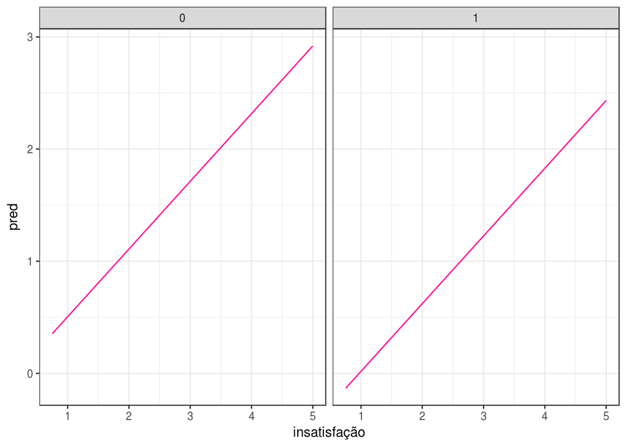

```r
modelo_plot = reclamacoes_l %>%
  data_grid(insatisfação = seq_range(insatisfação, 10),
            lexico_id = seq_range(lexico_id, 4),
            erro = seq_range(erro, 3)) %>%
  add_predictions(modelo)

modelo_plot %>%
  ggplot(aes(x = insatisfação, y = pred)) +
  geom_line(aes(group = lexico_id), color = "deeppink") +
  facet_grid(. ~ lexico_id)
```

Em que Léxico Op30 = 0 e Léxico Sent = 1.

Regressão múltipla foi utilizada para analisar se insatisfação real e tipo de léxico têm uma associação significativa com o erro na estimativa de insatisfação da reclamação. Os resultados da regressão indicam que um modelo com os 2 preditores no formato Erro = insatisfação + léxico explicam 53,38% da variância da variável de resposta (R² = 53,38). Considerando o contexto do problema, este R² é relativamente alto, pois o erro, um fator crítico, é explicado em 50% apenas pela insatisfação e pelo tipo de léxico. As duas variáveis indepentens oferecem estimativas significantes para o modelo. A Insatisfação, medida em uma escala de 0 a 5, tem uma relação significativa com o erro (b = [0,54; 0,66], IC com 95%), assim como léxico medido como sentimento_op30 (0) e sentimento_sent (1) (b = [-0,63; -0,33], IC com 95%). O aumento de 1 unidade de insatisfação produz uma mudança de 0.54 a 0.66 no valor do erro, e a mudança do léxico op30 para sent altera o valor do erro entre -0.63 e -0.34. Pelo gráfico acima podemos interpretar algo semelhante. O léxico Op30 (representado por 0) indica um erro relativamente maior.

Esse modelo encontrado foi o mais significativo dentre as opções que testamos. Outros modelos avaliados, por exemplo, foram:

$$erro ~> insatisfação + lexicoId + palavras$$
$$erro ~> comprimentoInsatisfacao + avaliadores$$
$$erro ~> semStopwords + insatisfação$$
Dentre outros …

Também tentamos usar TF-IDF para gerar pesos para as palavras de cada reclamação e utilizar esse peso ponderado como fator para calcular, junto ao léxico, a significância do sentimento da palavra.  
Todas essas abordagens levaram a resultados poucos significativos (ou um R² abaixo de 10% ou modelos com muitas variáveis cujo estimativa não era conclusiva / significante).  
Por fim, para o cálculo do sentimento, fizemos o seguinte ajuste: uma palavra em caixa alta tem um sentimento maior (o dobro) que outras (seja o sentimento positivo ou negativo). O código para esse cálculo fizemos no outro script fornecido pelo professor (~/code/calcula-sentimentos.Rmd). Essa abordagem tem alguns problemas, mas foi a melhor encontrada pelo grupo